# Análisis de conglomerados (Hierarchical clustering) & dendrogramas en R (En construcción)

Rubén F. Bustillo

2020-02-08

Esta entrada presenta algunas de las herramientas disponibles en R que permiten realizar análisis de conglomerados (o clusters) y representar los grupos y los resultados obtenidos en dendrogramas.

# Introducción

El análisis de conglomerados jerárquico que abordamos en este post, en inglés Hierarchical Cluster Analysis, es una alternativa al conocido [Análisis Cluster de k-Medias](https://www.ibm.com/support/knowledgecenter/es/SSLVMB_sub/statistics_mainhelp_ddita/spss/base/idh_quic.html), que trataremos en una futura entrada. El Análisis de Conglomerados Jerárquico pretende identificar grupos homogéneos de variables en función de alguna característica. Consecuentemente, al realizar este proceso, se busca ir combinando las agrupaciones hasta que finalmente quede solamente un grupo con características más diferenciadas. Esta metodología para realizar conglomerados no requiere que se preestablezca un número de clusters determinado, como si necesita el Análisis de k-Medias, y suele completarse con la realización de un tipo de gráfico particular, llamado [dendrograma](https://es.wikipedia.org/wiki/Dendrograma), que permite visualizar las agrupaciones en forma de árbol donde se van representando los datos por subcategorías.

## Paquetes

En primer lugar descargamos los paquetes requeridos para nuestro análisis:

```r
library(dendextend)
library(factoextra)
library(NbClust)
library(pvclust)
library(flexclust)
library(readxl)
```

# Dataset: Coeficientes de participación sectorial del VAB de las regiones peruanas

En esta ocasión vamos a trabajar con los **coeficientes de participación sectorial del Valor Agregado Bruto por regiones de Perú para los años 2001 y 2012**. Es decir, en los siguientes apartados se realizará un análisis de conglomerados jerárquico poniendo como pretexto examinar las similitudes entre regiones peruanas en función de su participación sectorial relativa en los años mencionados. Se buscará, por tanto, examinar similitudes regionales en términos de composición sectorial del VAB. En cierta medida este análisis podría servir como complemento del análisis realizado en [este](https://rquer.netlify.com/treemap_peru/) post anterior, donde se examinaba el peso sectorial de cada región peruana sobre la economía departamental y nacional en 2016.

La información sobre la participación relativa sectorial de las regiones peruanas las hemos obtenido del [Instituto Nacional de Estadística e Informática del Perú (INEI)](https://www.inei.gob.pe/). Como en este caso tenemos las participaciones sectoriales-regionales guardadas en un archivo excel en nuestro ordenador, empezamos cargando dichos archivos, uno para el año 2001 y otro para el año 2012, utilizando el paquete {readxl} y la función `read_excel()`.

```r
ddendvab01 <- read_excel("datasets/ddendvab01.xlsx")
ddendvab12 <- read_excel("datasets/ddendvab12.xlsx")
```

```r
ddendvab01
```

```
## # A tibble: 24 x 10
##    Name  agrvab01 minvab01 manvab01 convab01 comvab01 tycvab01 ryhvab01 sguvab01
##    <chr>    <dbl>    <dbl>    <dbl>    <dbl>    <dbl>    <dbl>    <dbl>    <dbl>
##  1 AMA       40.7    0.290    11.0      1.91    10.0      8.48     2.88    10.8
##  2 ANC       10.9   27.6      15.7      4.39     6.78     7.26     2.11     5.62
##  3 APU       27.4    0.905    10.2      9.10    13.8      3.36     4.24    18.2
##  4 ARE       15.3    5.96     18.8      5.80    16.9      8.67     2.97     4.14
##  5 AYA       27.4    2.51     12.2      5.05    16.2      4.46     2.38    16.1
##  6 CAJ       19.9   31.3      10.8      4.80     9.25     3.51     2.34     6.61
##  7 CUS       13.4   10.3      13.0      7.65    15.7      7.17     6.79     8.39
##  8 HUAV      17.0    7.98      3.04     1.04     5.97     1.46     1.10     7.72
##  9 HUAC      29.2    7.04     10.0      1.62    15.0     10.8      3.96    10.4
## 10 ICA       19.4    4.77     19.5      3.74    14.7      9.23     4.32     5.93
## # ... with 14 more rows, and 1 more variable: otrvab01 <dbl>
```

```r
ddendvab12
```

```
## # A tibble: 24 x 10
##    Name  agrvab12 minvab12 manvab12 convab12 comvab12 tycvab12 ryhvab12 sguvab12
##    <chr>    <dbl>    <dbl>    <dbl>    <dbl>    <dbl>    <dbl>    <dbl>    <dbl>
##  1 AMA      33.2     0.316     8.41    13.3      8.72     8.43     2.72    12.8
##  2 ANC       7.30   26.2      12.2      7.49     7.60     8.74     2.55     6.85
##  3 APU      24.0     0.542     8.12    17.1     11.9      3.12     4.20    20.7
##  4 ARE      12.4     8.64     17.3     13.9     14.5      8.51     2.87     3.99
##  5 AYA      18.8    10.2       7.69    17.5     12.9      4.07     2.20    14.7
##  6 CAJ      18.9    20.0      11.3      8.47    10.5      4.54     3.01     9.61
##  7 CUS      10.3    20.1       7.98    17.1     11.5      5.88     6.23     6.96
##  8 HUAV     14.0     8.07      3.02     2.14     7.36     2.00     1.47    12.6
##  9 HUAC     23.7     3.10      9.70     4.08    15.9     13.0      4.79    13.4
## 10 ICA      16.4     8.02     20.2     13.5     10.8      8.05     3.56     4.84
## # ... with 14 more rows, and 1 more variable: otrvab12 <dbl>
```

Antes de empezar a operar indicamos que los nombres de las filas (rownames) son los que se encuentran en la columna con el nombre `name` y, posteriormente, quitamos dicha columna de nuestro dataset dejando únicamente los valores sobre los que vamos a trabajar.

```r
rownames(ddendvab01)<- ddendvab01$Name
rownames(ddendvab01)
```

```
##  [1] "AMA"  "ANC"  "APU"  "ARE"  "AYA"  "CAJ"  "CUS"  "HUAV" "HUAC" "ICA"
## [11] "JUN"  "LLIB" "LAM"  "LIM"  "LORE" "MDD"  "MOQ"  "PAS"  "PIU"  "PUN"
## [21] "SMA"  "TAC"  "TUM"  "UCA"
```

```r
ddendvab01$Name <- NULL
ddendvab01
```

```
## # A tibble: 24 x 9
##    agrvab01 minvab01 manvab01 convab01 comvab01 tycvab01 ryhvab01 sguvab01
##  *    <dbl>    <dbl>    <dbl>    <dbl>    <dbl>    <dbl>    <dbl>    <dbl>
##  1     40.7    0.290    11.0      1.91    10.0      8.48     2.88    10.8
##  2     10.9   27.6      15.7      4.39     6.78     7.26     2.11     5.62
##  3     27.4    0.905    10.2      9.10    13.8      3.36     4.24    18.2
##  4     15.3    5.96     18.8      5.80    16.9      8.67     2.97     4.14
##  5     27.4    2.51     12.2      5.05    16.2      4.46     2.38    16.1
##  6     19.9   31.3      10.8      4.80     9.25     3.51     2.34     6.61
##  7     13.4   10.3      13.0      7.65    15.7      7.17     6.79     8.39
##  8     17.0    7.98      3.04     1.04     5.97     1.46     1.10     7.72
##  9     29.2    7.04     10.0      1.62    15.0     10.8      3.96    10.4
## 10     19.4    4.77     19.5      3.74    14.7      9.23     4.32     5.93
## # ... with 14 more rows, and 1 more variable: otrvab01 <dbl>
```

```r
rownames(ddendvab12)<-ddendvab12$Name
rownames(ddendvab12)
```

```
##  [1] "AMA"  "ANC"  "APU"  "ARE"  "AYA"  "CAJ"  "CUS"  "HUAV" "HUAC" "ICA"
## [11] "JUN"  "LLIB" "LAM"  "LIM"  "LORE" "MDD"  "MOQ"  "PAS"  "PIU"  "PUN"
## [21] "SMA"  "TAC"  "TUM"  "UCA"
```

```r
ddendvab12$Name <- NULL
ddendvab12
```

```
## # A tibble: 24 x 9
##    agrvab12 minvab12 manvab12 convab12 comvab12 tycvab12 ryhvab12 sguvab12
##  *    <dbl>    <dbl>    <dbl>    <dbl>    <dbl>    <dbl>    <dbl>    <dbl>
##  1    33.2     0.316     8.41    13.3      8.72     8.43     2.72    12.8
##  2     7.30   26.2      12.2      7.49     7.60     8.74     2.55     6.85
##  3    24.0     0.542     8.12    17.1     11.9      3.12     4.20    20.7
##  4    12.4     8.64     17.3     13.9     14.5      8.51     2.87     3.99
##  5    18.8    10.2       7.69    17.5     12.9      4.07     2.20    14.7
##  6    18.9    20.0      11.3      8.47    10.5      4.54     3.01     9.61
##  7    10.3    20.1       7.98    17.1     11.5      5.88     6.23     6.96
##  8    14.0     8.07      3.02     2.14     7.36     2.00     1.47    12.6
##  9    23.7     3.10      9.70     4.08    15.9     13.0      4.79    13.4
## 10    16.4     8.02     20.2     13.5     10.8      8.05     3.56     4.84
## # ... with 14 more rows, and 1 more variable: otrvab12 <dbl>
```

Nótese que en nuestro casoparticular no necesitamos estandarizar los datos, aunque dependiendo de las características de las observaciones a analizar cabría la posibilidad de que fuera necesario normalizarlos antes de realizar el análisis de conglomerados.

# Medidas de distancia de los conglomerados: Distancia Euclídea

Una de las medidas más utilizadas para determinar el grado de similitud o disimilitud entre observaciones es **la distancia euclídea (o distancia euclidiana)**, distnacia que suele ser la que R nos muestra por defecto. No obstante téngase en cuenta que existen otro tipo de medidas alternativas para medir la distancia de las similitudes (o diferencias) entre observaciones como puede ser la distancia Manhattan, Canberra, binaria o la distancia en función del coeficiente de correlación de Pearson o de Kendall. [La distancia euclídea](https://www.ecured.cu/Distancia_eucl%C3%ADdea) en un espacio bidimensional, cuya formulación deriva del Teorema de Pitágoras, sería la distancia “ordinaria” entre dos puntos en un plano cartesiano o la longitud del segmento de recta que une dichos puntos. La formulación básica para un espacio de dos dimensiones puede ser fácilmente ajustada, como se observa en el link, para estimar la distancia euclídea entre diversos puntos en un espacio n-dimensional.

Del paquete {stats} podemos utilizar la función `dist()` para obtener la **matriz de distancias**. Como hemos indicado, la metodología que viene por defecto es la distancia euclídea, aunque podemos indicar otros métodos con el comando `method= " "`. De forma alternativa podemos utilizar la función `get_dist()` del paquete {factoextra}, que básicamente nos devuelve el mismo resultado. No obstante, este paquete incluye la función `fviz_dist()` que nos permite visualizar en un heat map dicha matriz de distancias, donde, por ejemplo, podemos indicar que nos muestre en color rojo las distancias mayores y el azul los valores más pequeños (más similitud). Veamos cómo sería su aplicación para el año 2001 y 2012:

## 2001:

```r
vab01.dist <- dist(ddendvab01, method="euclidean") # del paquete {stats}
vab01.dist
```

```
##            AMA       ANC       APU       ARE       AYA       CAJ       CUS
## ANC  41.621436
## APU  18.047724 36.185017
## ARE  30.021817 24.691644 23.839064
## AYA  16.554823 34.020496  6.208849 20.644736
## CAJ  38.047913 14.332659 34.005720 30.288998 32.085124
## CUS  30.851679 20.917730 20.952008 10.474156 19.184760 24.754864
## HUAV 49.379983 43.214779 47.100719 39.618122 45.992290 50.113661 41.207654
## HUAC 14.563109 31.020545 14.663112 20.693440 10.938199 28.056333 19.119588
## ICA  24.848530 26.108158 20.273682  6.549371 16.734286 29.903857 11.924584
## JUN  29.334238 18.465444 23.634085  8.500016 20.830363 24.508864  9.068033
## LLIB 22.893482 24.703846 20.186675  9.910558 17.275019 27.946010 14.159531
## LAM  32.690369 33.539146 25.417764 12.757188 22.224754 37.256568 16.005144
## LIM  42.448918 32.213563 34.084953 16.365218 32.109701 41.657454 20.255644
## LORE 27.189348 20.493740 19.207146 12.011300 16.362440 21.851088  6.107261
## MDD  46.450165 15.954397 41.084850 35.150484 39.212873 12.379022 28.442434
## MOQ  47.218150 19.156303 42.258384 28.258812 39.696971 27.257923 28.964831
## PAS  66.013294 34.819854 61.760574 57.013411 60.325105 29.321506 50.853216
## PIU  32.195628 24.790691 24.294134  5.051201 21.270858 30.443947 10.386381
## PUN  25.675252 20.727531 18.858357 11.005873 16.059123 24.051961  8.339680
## SMA  15.439033 33.778222  9.924107 17.194065  8.041998 33.528965 17.732080
## TAC  39.722017 14.264120 32.032396 19.593611 30.039355 21.113580 13.973553
## TUM  28.742797 33.251174 21.188740 17.402234 19.877540 37.069366 16.717167
## UCA  22.030579 30.353435 15.950262 11.094928 12.141822 31.568806 12.726203
##           HUAV      HUAC       ICA       JUN      LLIB       LAM       LIM
## ANC
## APU
## ARE
## AYA
## CAJ
## CUS
## HUAV
## HUAC 47.048697
## ICA  42.048680 16.144614
## JUN  36.095063 19.217288 10.342334
## LLIB 40.163578 16.505921  6.449034 10.387561
## LAM  42.156697 22.843906 15.634843 17.558267 20.305233
## LIM  34.813952 33.994612 21.006789 19.330544 24.120915 17.941590
## LORE 40.619487 14.991482 11.834205  8.961090 13.176571 16.932385 23.839085
## MDD  50.431473 34.817442 35.966427 28.789788 35.350279 40.157842 42.807043
```

[output cut: 41 more lines]

```
## ICA
## JUN
## LLIB
## LAM
## LIM
## LORE
## MDD
## MOQ
## PAS
## PIU
## PUN
## SMA
## TAC
## TUM  23.104300
## UCA  24.607014 15.527966
```

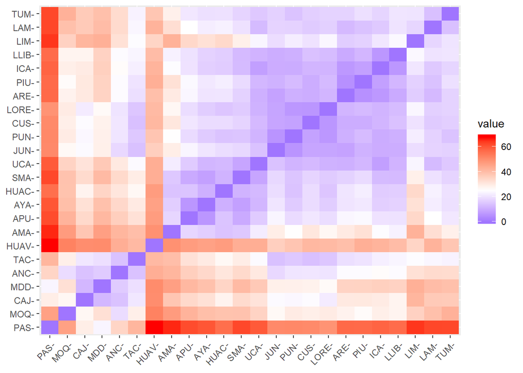

```r
fviz_dist(vab01.dist, gradient = list(low = "blue", mid = "white", high = "red"))
```

## 2012:

```r
vab12.dist <- dist(ddendvab12, method="euclidean")
vab12.dist
```

```
##            AMA       ANC       APU       ARE       AYA       CAJ       CUS
## ANC  38.725104
## APU  14.334401 37.535336
## ARE  26.857734 21.551730 25.920878
## AYA  19.066865 26.573035 12.884694 17.992101
## CAJ  25.536046 16.281142 25.105195 17.852965 15.054203
## CUS  31.486403 15.626975 28.023304 16.821915 15.999396 13.440683
## HUAV 44.774473 36.918034 45.097799 38.697638 41.680021 39.746629 41.763707
## HUAC 16.124127 32.073449 18.734152 21.374924 18.877377 21.189728 27.491624
## ICA  23.492220 23.938052 23.864184  7.219435 17.622811 17.113385 19.047795
## JUN  25.700331 18.587843 25.881540  9.926721 18.072184 16.213197 17.152572
## LLIB 22.428204 23.388767 25.269587 11.276278 19.951904 15.868357 21.943771
## LAM  32.747540 31.540200 30.595265 17.426478 26.003181 28.862556 27.510768
## LIM  39.632725 31.037112 38.021719 20.564793 33.628855 33.438212 32.175848
## LORE 23.533469 26.423031 20.532698 12.996390 16.931608 19.884982 21.608641
## MDD  38.911172 12.204969 36.948438 27.274949 26.757485 16.631138 17.876028
## MOQ  36.977947 17.503881 33.822161 16.720449 23.970663 20.473819 16.273393
## PAS  51.361382 21.660365 49.858966 39.905884 38.363543 27.545255 27.400714
## PIU  26.541951 24.839544 25.416345  6.653681 19.893671 19.983088 21.420017
## PUN  20.586878 24.131724 20.582768 12.462531 16.056465 17.868064 20.887060
## SMA  10.847204 34.411009 15.123829 20.482051 17.935366 22.212056 28.633616
## TAC  32.545156 17.768325 30.910533 14.278362 22.373274 20.296460 17.551315
## TUM  27.752252 30.896048 26.267661 21.018436 23.724162 28.395836 27.371578
## UCA  21.448732 29.517013 21.235467 15.016512 19.092320 21.516910 24.745267
##           HUAV      HUAC       ICA       JUN      LLIB       LAM       LIM
## ANC
## APU
## ARE
## AYA
## CAJ
## CUS
## HUAV
## HUAC 41.703660
## ICA  41.947093 20.173292
## JUN  31.776615 18.163288 13.946674
## LLIB 38.582729 18.824252  7.223533 13.673173
## LAM  39.091376 22.098589 22.699841 16.719344 24.603350
## LIM  32.856604 29.922962 25.633717 19.312619 26.019944 14.864424
## LORE 35.973120 13.412901 15.285133 11.100172 16.088870 13.384605 19.191752
## MDD  38.823920 30.557894 29.532973 22.207632 28.549808 32.929429 35.356501
```

[output cut: 41 more lines]

```
## ICA
## JUN
## LLIB
## LAM
## LIM
## LORE
## MDD
## MOQ
## PAS
## PIU
## PUN
## SMA
## TAC
## TUM  14.912244
## UCA  17.489030 15.500177
```

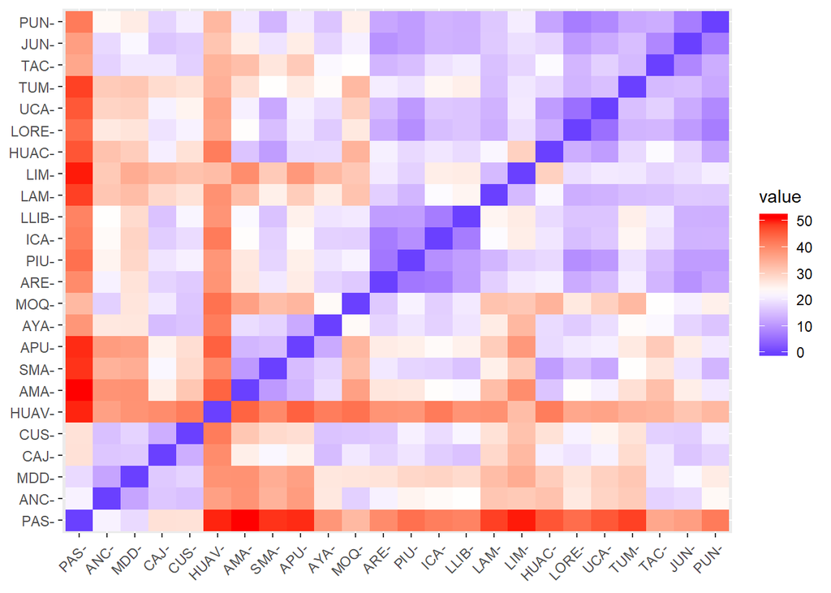

```r
fviz_dist(vab12.dist, gradient = list(low = "blue", mid = "white", high = "red"))
```

# Método de agrupamiento:

Una vez tenemos estimadas las distancias, según el método escogido, un segundo elemento a considerar es cómo medir las diferencias entre los grupos de observaciones o conglomerados. De nuevo, existen diversas propuestas para llevar a cabo este proceso y, dependiendo del criterio escogido las agrupaciones obtenidas, y el dendrograma resultante, mostrará diferencias significativas. Por tanto, no podemos hablar de una solución óptima, sino que la metodología escogida dependerá del caracter de los datos, del investigador y de su criterio. Los métodos más utilizados son los siguiente:

- **Distancia mínima (máxima similitud) o** *single linkage*: La distancia según este criterio vendría dada por la mínima distancia entre los distintos componentes.
- **Distancia máxima (mínima similitud) o** *complete linkage*: La distancia según este criterio vendría dada por la máxima distancia entre los distintos componentes.
- **Distancia promedio o** *average linkage*: La distancia según este criterio vendría dada por el promedio de las distancias de los componentes de un conglomerado con respecto al promedio de las distancias del otro grupo.
- **En base los centroides o** *centroid linkage*: La distancia según este criterio vendría dada por la mayor semejanza entre los centroides de los clusters.
- **Método Ward (mínima varianza)**: La distancia según este criterio vendría dada por el menor incremento en el valor total de la suma de los cuadrados de las diferencias existentes, dentro de cada conglomerado, de cada observación con respecto al centroide del cluster.

Para evitar ser excesivamente repetitivos en los siguientes apartados vamos a mostrar cómo realizar el proceso siguiendo el procedimiento de agrupación según la distancia promedio (average linkage) y según el método Ward. Podremos de esta forma comprobar las diferencias en los resultado obtenido dependiendo del criterio escogido.

## Average linkage:

## 2001

Para llevar a cabo la agrupación de conglomerados jerárquicos utilizamos la función `hclust()` del paquete {stats}.

```r
HCvab01<- hclust(vab01.dist, method="average")
HCvab01
```

```
##
## Call:
## hclust(d = vab01.dist, method = "average")
##
## Cluster method   : average
## Distance         : euclidean
## Number of objects: 24
```

Una vez hemos relizado la agrupación podemos **representar dichos conglomerados en un dendrograma**. Para ello tenemos diversas posibilidades utilizando la función `plot()` del paquete {graphics}, obteniendo dendrogramas que muestran ligeras diferencias, o con otros paquetes de R como {factoextra}:

### Opción 1.

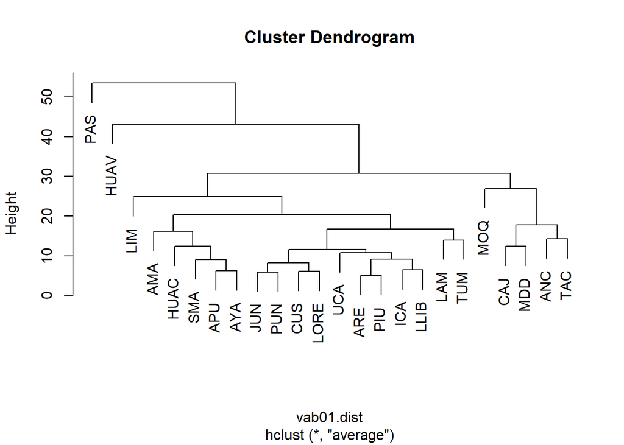

```r
plot(HCvab01)
```

### Opción 2.

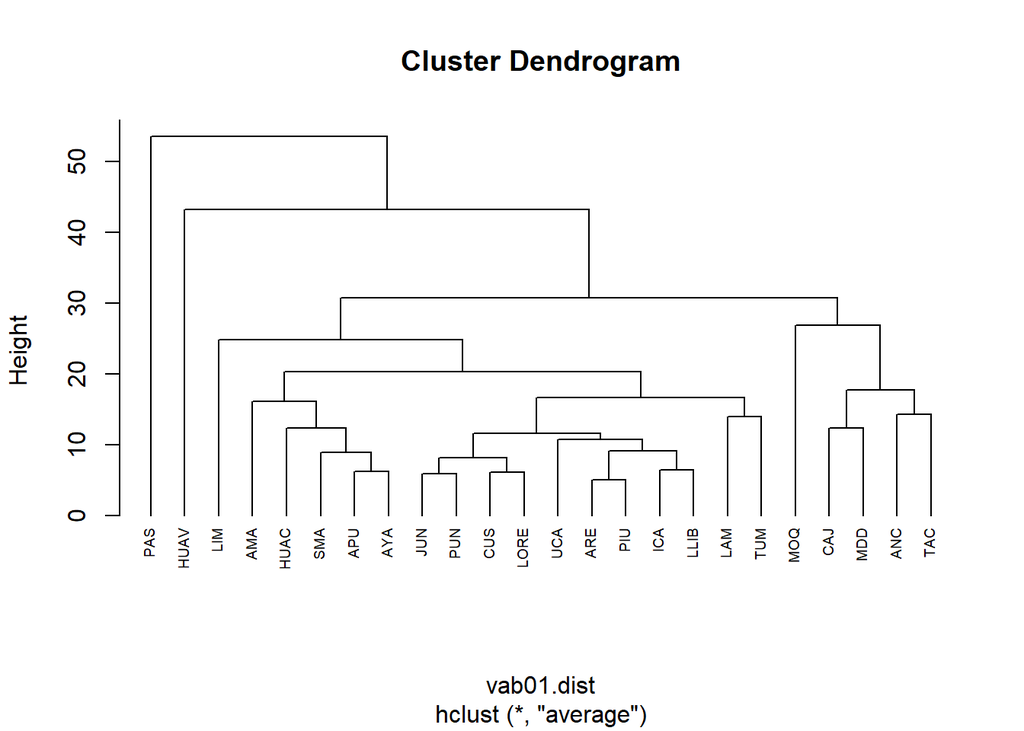

```r
plot(HCvab01, hang= -1, cex=0.6)
```

### Opción 3.

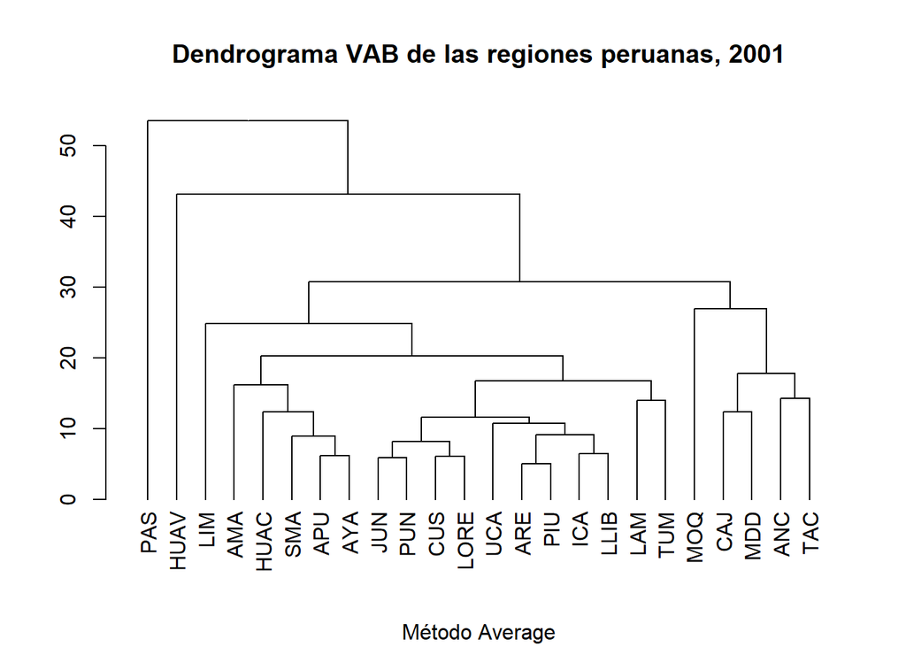

```r
DNDvab01<- as.dendrogram(HCvab01)
DNDvab01
## 'dendrogram' with 2 branches and 24 members total, at height 53.44587
plot(DNDvab01,
     main= "Dendrograma VAB de las regiones peruanas, 2001",
     sub= "Método Average")
```

### Opción 4.

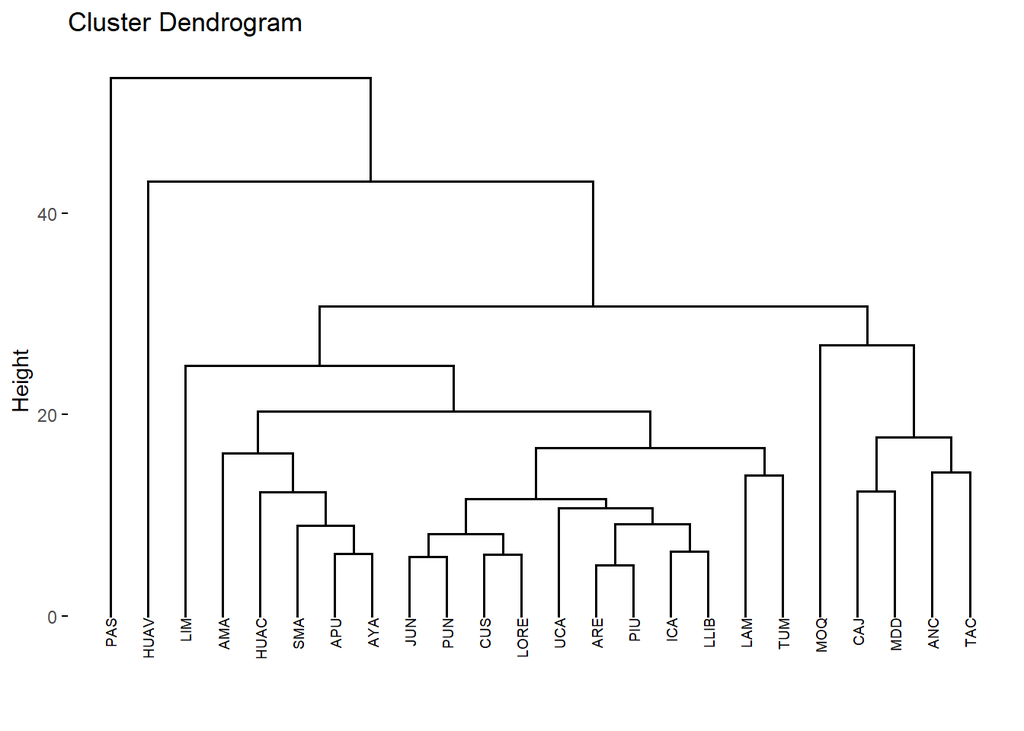

```r
DNDvab01_2<-fviz_dend(DNDvab01, cex=0.5)
DNDvab01_2
```

### Opción 5.

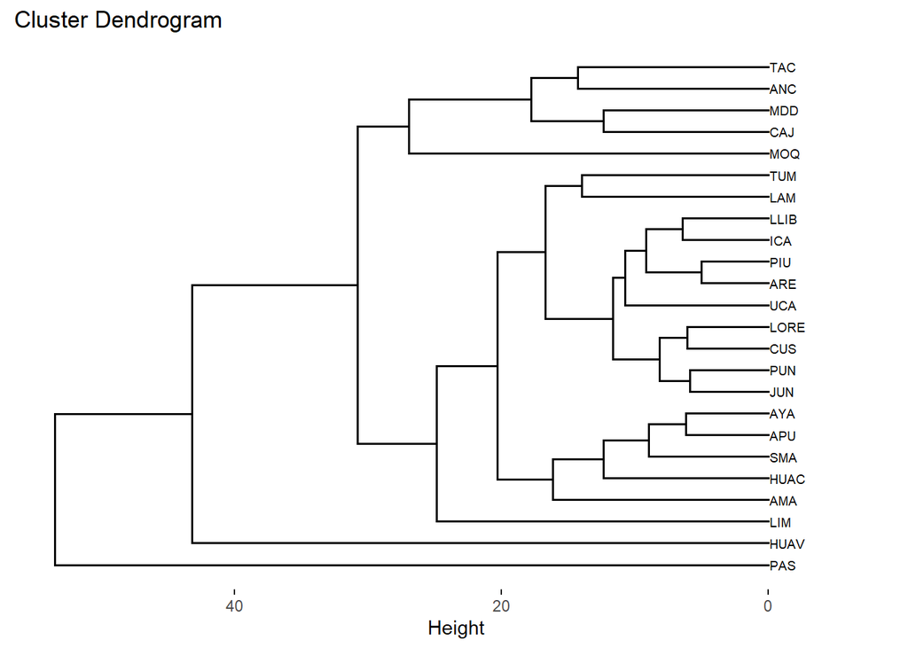

```r
fviz_dend(DNDvab01, cex=0.5, horiz=TRUE)
```

## 2012

Para el año 2012 el Análisis de Conglomerados Jerárquico utilizando el método de distancia promedio (*average linkage*) y su correspondiente dendrograma sería el siguiente:

```r
HCvab12<- hclust(vab12.dist, method="average")
```

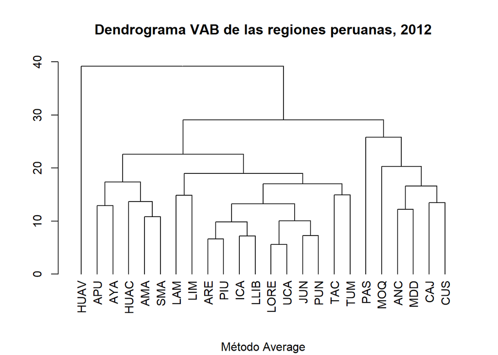

```r
DNDvab12<- as.dendrogram(HCvab12)
DNDvab12
## 'dendrogram' with 2 branches and 24 members total, at height 39.14731
plot(DNDvab12,
     main= "Dendrograma VAB de las regiones peruanas, 2012",
     sub= "Método Average")
```

## Método de Ward:

Para realizar un dendrograma utilizando otro método de agrupamiento únicamente debemos seleccionar el criterio escogido. la función `hclust()` permite escoger entre: “ward.D”, “ward.D2”, “single”, “complete”, “average”, “mcquitty”, “median” o “centroid”. Para realizar el análisis aplicando, por ejemplo, el método Ward indicaremos `method= "ward.D2" en la función`hclust()` (véase: Murtagh, F., & Legendre, P. 2014. Ward’s hierarchical agglomerative clustering method: which algorithms implement Ward’s criterion?. Journal of Classification, 31/3, 274-295)

### 2001

```r
HCvab01b<-hclust(vab01.dist, method="ward.D2")
```

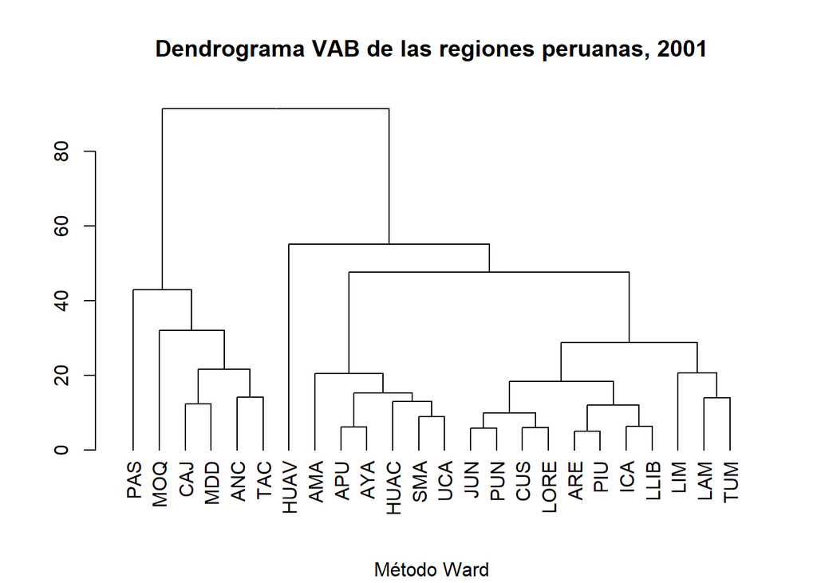

```r
DNDvab01b<- as.dendrogram(HCvab01b)
DNDvab01b
## 'dendrogram' with 2 branches and 24 members total, at height 91.3892
plot(DNDvab01b,
     main= "Dendrograma VAB de las regiones peruanas, 2001",
     sub= "Método Ward")
```

### 2012

```r
HCvab12b<-hclust(vab12.dist, method="ward.D2")
```

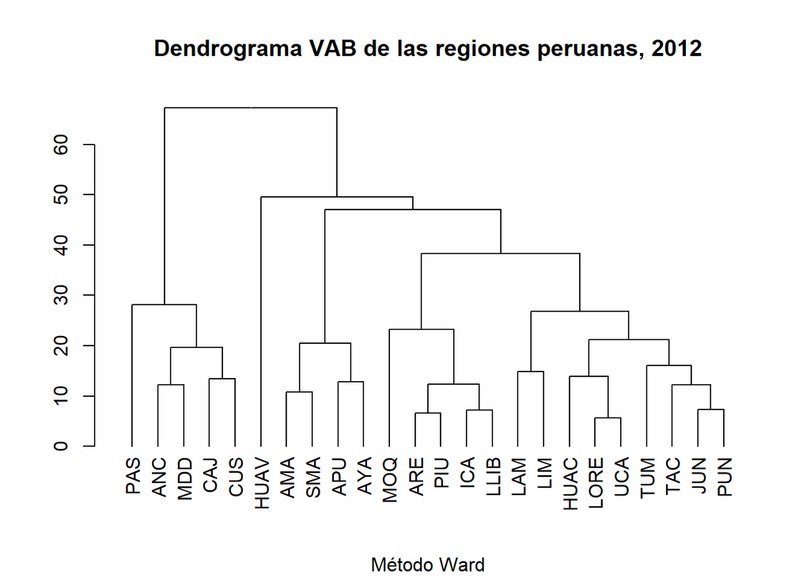

```r
DNDvab12b<- as.dendrogram(HCvab12b)
DNDvab12b
## 'dendrogram' with 2 branches and 24 members total, at height 67.22437
plot(DNDvab12b,
     main= "Dendrograma VAB de las regiones peruanas, 2012",
     sub= "Método Ward")
```

# Comparación entre dendrogramas

Con el paquete {dendextend} podemos visualizar y comparar dendrogramas de conglomerados jerárquicos. La comparación visual se realiza utilizando la función `tanglegram()`, que sitúa los dendrogramas que queremos comparar uno enfrente del otro y conecta sus observaciones mediante líneas. En nuestro ejercicio, de nuevo por motivos de simplicidad, vamos a utilizar únicamente los dendrogramas de 2001 y 2012 estimados con el criterio de agrupamiento de promedios.

## VAB 2001 vs VAB 2012

En primer lugar creamos una lista con los dendrogramas `DNDvab01` y `DNDvab12` que denominaremos `dend_listvab`.

```r
#creamos una lista con los dos dendrograms VAB 01 Y 12 (Average)

dend_listvab<- dendlist(DNDvab01,DNDvab12)
dend_listvab
## [[1]]
## 'dendrogram' with 2 branches and 24 members total, at height 53.44587
##
## [[2]]
## 'dendrogram' with 2 branches and 24 members total, at height 39.14731
##
## attr(,"class")
## [1] "dendlist"
```

A la hora de comparar los dendrogramas podemos escoger entre distintas posibles clasificaciones utilizando la función `untangle()`. las opciones a escoger son las siguientes: “labels”, “ladderize”, “random”, “step1side”, “step2side”, “DendSer”. Veamos gráficamente la diferencia entre algunas de ellas:

### method = “labels”

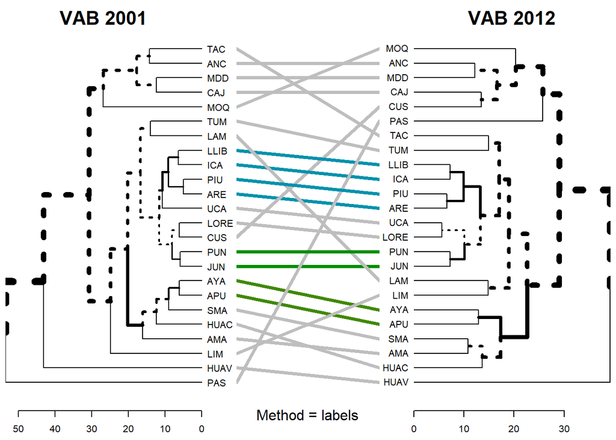

```r
dendlist(dend_listvab) %>%
  untangle(method = "labels") %>%
  tanglegram(sub= "Method = labels",
             main_left= "VAB 2001",
             main_right = "VAB 2012",
             cex_sub=1)
```

### method = “step1side”

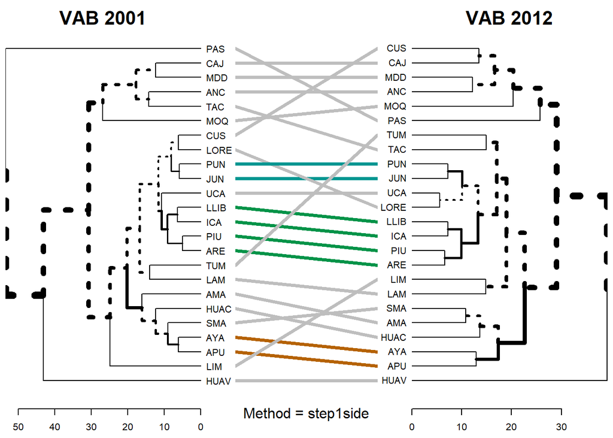

```r
dendlist(dend_listvab) %>%
  untangle(method ="step1side") %>%
  tanglegram(sub= "Method = step1side",
             main_left= "VAB 2001",
             main_right = "VAB 2012",
             cex_sub=1)
```

### method = “ladderize”

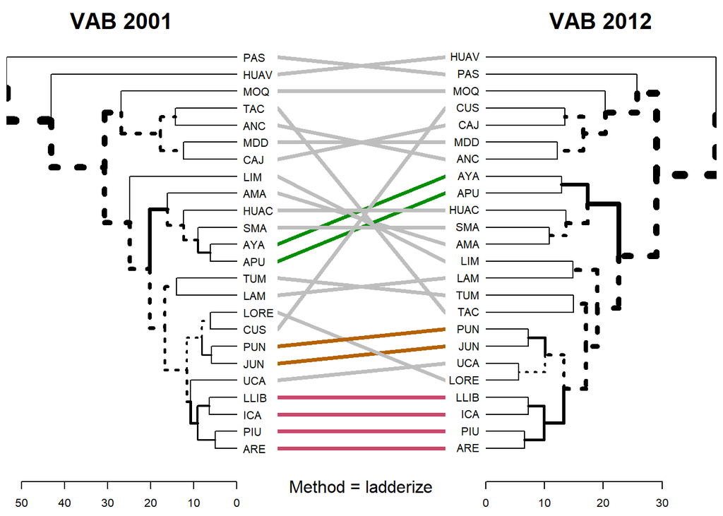

```r
dendlist(dend_listvab) %>%
  untangle(method ="ladderize") %>%
  tanglegram(sub= "Method = ladderize",
             main_left= "VAB 2001",
             main_right = "VAB 2012",
             cex_sub=1)
```

### customizado

Existen diversas opciones para customizar el tanglegram que se pueden consultar en la [documentación del paquete {tanglegram}](https://www.rdocumentation.org/packages/dendextend/versions/1.13.3/topics/tanglegramV). Adicionalmente, con la función `entanglement()` podemos indicar la fortaleza del entrelazamiento o enredo (*entanglement*) de los dos dendragramas. El *entanglement* corresponde a una medida entre 1 (entrelazamiento/enredo fuerte o completo) y 0 (no entrelazamiento/enredo). Por consiguiente, un valor más cercano a 0 será indicativo de que entre los dos dendrogramas existe una mayor correspondencia que si el resultado fuera mayor.

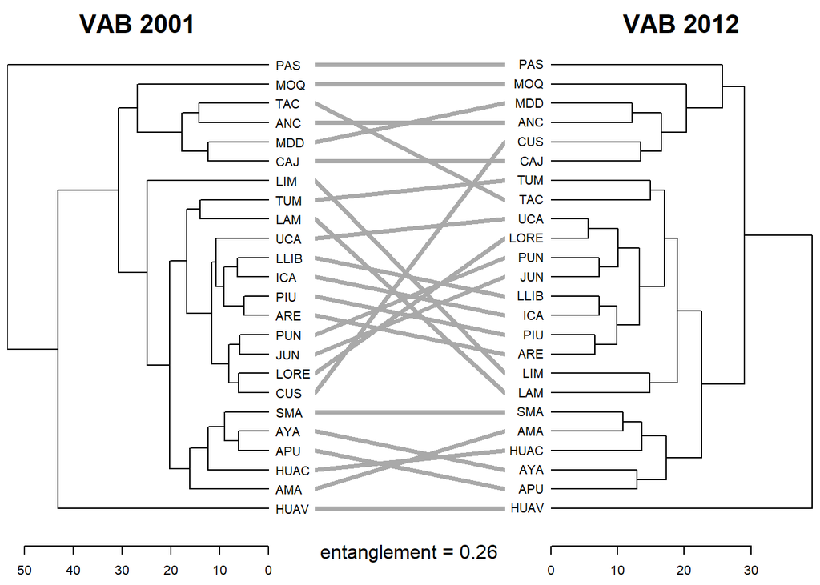

```r
tanglegram(DNDvab01,DNDvab12,
           sort=T,
           main_left= "VAB 2001",
           main_right = "VAB 2012",
           common_subtrees_color_lines = FALSE,
           common_subtrees_color_branches = TRUE,
           sub = paste("entanglement =", round(entanglement(dend_listvab), 2)),
           cex_sub=1,
           fast=TRUE)
```

## Average vs. Ward

De forma similar podemos comparar el dendrograma realizado siguiendo el criterio de clasificación según la distancia promedio y dendrograma realizado según el criterio Ward de mínima varianza. El procedimiento sería similar al realizado en el punto previo.

```r
#creamos una lista con los dos dendrograms (Average y Ward) para el año 2001

dend_listvabb<- dendlist(DNDvab01,DNDvab01b)
dend_listvabb
## [[1]]
## 'dendrogram' with 2 branches and 24 members total, at height 53.44587
##
## [[2]]
## 'dendrogram' with 2 branches and 24 members total, at height 91.3892
##
## attr(,"class")
## [1] "dendlist"
```

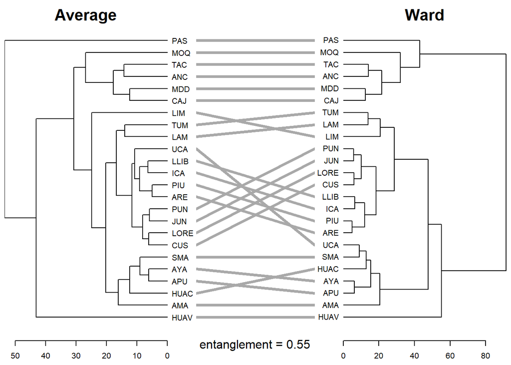

```r
tanglegram(DNDvab01,DNDvab01b,
           sort=T,
           main_left= "Average",
           main_right = "Ward",
           highlight_distinct_edges = T,
           common_subtrees_color_lines = FALSE,
           common_subtrees_color_branches = TRUE,
           sub = paste("entanglement =", round(entanglement(dend_listvabb), 2)),
           cex_sub=1,
           fast=TRUE)
```

# Correlación matrix entre dendogramas

Para obtener las **matrices de correlación de los dendrogramas** podemos hacer uso de la función `cor.dendlist()` del paquete {dendextend}. Esta función ofrece la posibilidad de escoger diversos coeficientes de correlación: “cophenetic” (viene establecido por defecto), “baker”, “common_nodes” o “FM_index”.

## Correlación cofenética (Cophenetic)

Como hemos enunciado, para obtener la matriz de correlación cofenética podemos utilizar la función `cor.dendlist()`. Las matrices de correlación para los conglomerados de 2001 y 2012 (average) y para los modelos Average vs. Ward en 2001 serían, por consiguiente, las siguientes:

```r
cor.dendlist(dend_listvab, method = "cophenetic") #average 2001 vs average 2012
```

```
##           [,1]      [,2]
## [1,] 1.0000000 0.6854301
## [2,] 0.6854301 1.0000000
```

```r
cor.dendlist(dend_listvabb, method= "cophenetic") #average vs ward en 2001
```

```
##           [,1]      [,2]
## [1,] 1.0000000 0.6865269
## [2,] 0.6865269 1.0000000
```

Coeficiente de correlación:

```r
cor_cophenetic(DNDvab01, DNDvab12)
```

```
## [1] 0.6854301
```

```r
cor_cophenetic(DNDvab01, DNDvab01b)
```

```
## [1] 0.6865269
```

## Correlación Baker

```r
cor.dendlist(dend_listvab, method = "baker")
```

```
##           [,1]      [,2]
## [1,] 1.0000000 0.7024245
## [2,] 0.7024245 1.0000000
```

```r
cor.dendlist(dend_listvabb, method = "baker")
```

```
##           [,1]      [,2]
## [1,] 1.0000000 0.8126997
## [2,] 0.8126997 1.0000000
```

Coeficiente de correlación:

```r
cor_bakers_gamma(DNDvab01, DNDvab12)
```

```
## [1] 0.7024245
```

```r
cor_bakers_gamma(DNDvab01b, DNDvab12b)
```

```
## [1] 0.4473367
```

## Grupos en colores

```r
source("https://github.com/traffordDataLab/assets/raw/master/theme/ggplot2/theme_lab.R")
```

Año 2001

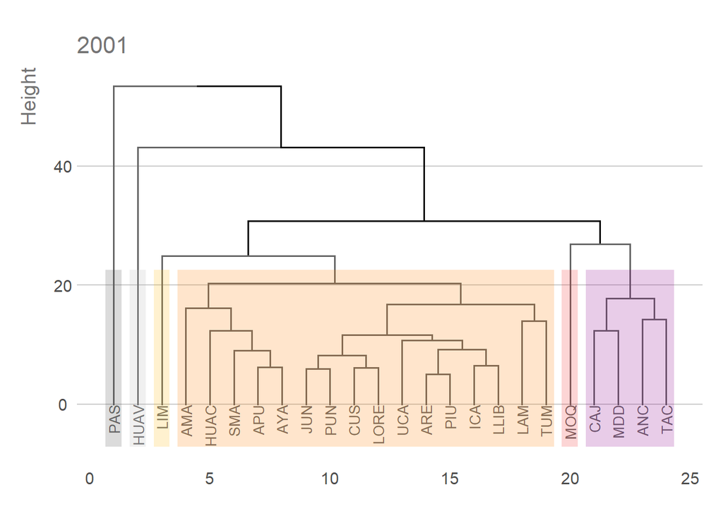

```r
fviz_dend(DNDvab01, k = 6, # Cut in four groups
          cex = 0.7, # label size
          k_colors = c("grey40", "grey40", "grey40", "grey40","grey40", "grey40"),
          color_labels_by_k = TRUE, # color labels by groups
          rect = TRUE, # Add rectangle around groups
          rect_border = c("grey30", "grey70","darkgoldenrod1"," darkorange1","firebrick2", "darkmagenta"),
          rect_fill = TRUE)+
  labs(title = NULL, subtitle = "2001",
       caption = NULL,
       x = NULL,
       #y = NULL,
       fill = NULL) +
  xlab(NULL)+
  #ylab(NULL)+
  theme_lab()+
  theme(panel.grid.major.x = element_blank(), legend.position = "right")
```

Año 2012

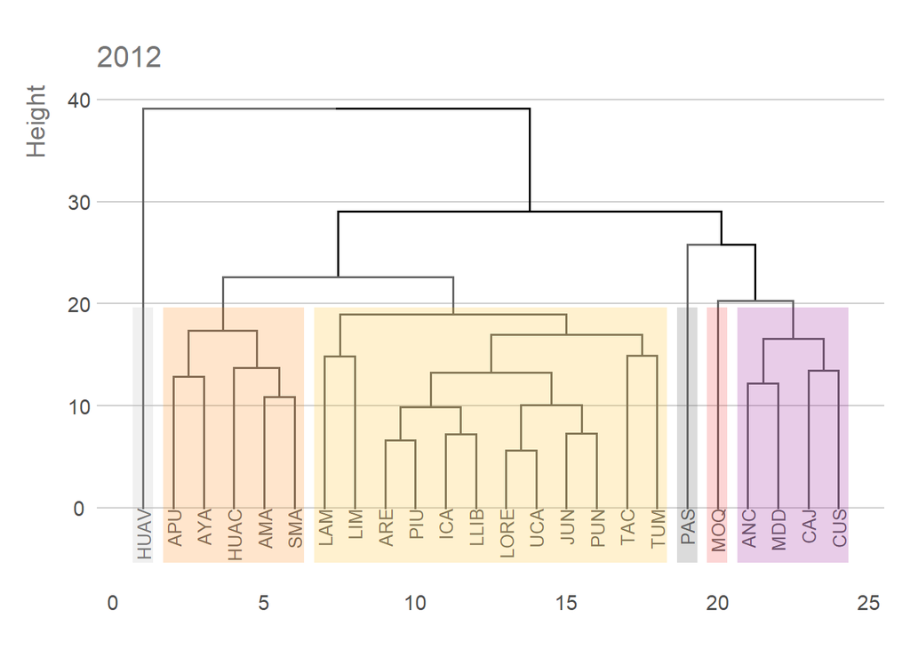

```r
fviz_dend(DNDvab12, k = 6, # Cut in four groups
          cex = 0.7, # label size
          k_colors = c("grey40", "grey40", "grey40", "grey40","grey40", "grey40"),
          color_labels_by_k = TRUE, # color labels by groups
          rect = TRUE, # Add rectangle around groups
          rect_border = c( "grey70", " darkorange1","darkgoldenrod1","grey30","firebrick2", "darkmagenta"),
          rect_fill = TRUE)+
  labs(title = NULL, subtitle = "2012",
       caption = NULL,
       x = NULL,
       #y = NULL,
       fill = NULL) +
  xlab(NULL)+
  #ylab(NULL)+
  theme_lab()+
  theme(panel.grid.major.x = element_blank(), legend.position = "right")
```